# 4_Linguistic_analys_partA.R

helianateixeira

2022-04-26

## Linguistic analysis - part A

author: Heliana Teixeira date: 28-07-2021; modified 26-04-2002 code credits to UDPipe C++ library and models provided by Milan Straka, https://github.com/ufal/udpipe

Using BBNJ dataset from Mariana Caldeira MSc Thesis. Considering key Messages within SWOT levels (#4), through time (Negotiation.phase #3). This script applies keyword extraction techniques to analyse plain text. ### load packages

```r
library(here)
```

linguistic analysis:

```r
library(udpipe)
library(textrank)
```

visualization:

```r
library(lattice)
library(wordcloud)
library(igraph)
library(ggraph)
library(ggplot2)
library(tidyverse)
```

### load data

```r
here::here()
```

```
## [1] "/Users/helianateixeira/OneDrive - Universidade de Aveiro/Rdir/TextMining"
```

```r
Fname.dat <- (here("Data", "SWOTcatsMessageTime.csv")) #edit file name
data <- read.csv(file = Fname.dat, header = TRUE, sep = ",", dec =".")
```

### pre-treatment

convert to factor some fields of interest for analysis

```r
data$SWOT.Cats<- as.factor(data$SWOT.Cats)
data$SWOT <- as.factor(data$SWOT)
data$Category <- as.factor(data$Category)
data$Negotiation.phase <- as.factor(data$Negotiation.phase)
```

generate datasets for factors to be analysed Category

```r
summary(data$Category) #check no. messages in each subset
```

```
##   I  II III  IV   V  VI
## 155 201 159  21  36  36
```

```r
dataCatsI <- data %>% filter(Category=="I")
dataCatsII <- data %>% filter(Category=="II")
dataCatsIII <- data %>% filter(Category=="III")
dataCatsIV <- data %>% filter(Category=="IV")
dataCatsV <- data %>% filter(Category=="V")
dataCatsVI <- data %>% filter(Category=="VI")
```

Negotiation Phase

```r
summary(data$Negotiation.phase) #check no. messages in each subset
```

```
## BBNJ WG     IGC PrepCom
##      96     291     221
```

```r
dataBBNJWG <- data %>% filter(Negotiation.phase=="BBNJ WG")
dataPrepCom <- data %>% filter(Negotiation.phase=="PrepCom")
dataIGC <- data %>% filter(Negotiation.phase=="IGC")
```

### 1. Linguistic analysis

ignore - for usage out of function:

```r
# ud_model <- udpipe_download_model(language = "english")
# ud_model <- udpipe_load_model(ud_model$file_model)
# x <- udpipe_annotate(ud_model, x = data$Message) #' Select field for analysis
# x <- as.data.frame(x)
```

download udpipe EN version file

```r
UDP_file <- udpipe_download_model(language = "english") #file
```

```
##  - This model has been trained on version 2.5 of data from https://universaldependencies.org
```

```
##  - The model is distributed under the CC-BY-SA-NC license: https://creativecommons.org/licenses/by-nc-sa/4.0
```

```
##  - Visit https://github.com/jwijffels/udpipe.models.ud.2.5 for model license details.
```

```
##  - For a list of all models and their licenses (most models you can download with this package have either a CC-BY-SA or a CC-BY-SA-NC license) read the documentation at ?udpipe_download_model. For building your own models: visit the documentation by typing vignette('udpipe-train', package = 'udp…
```

define new udpipe function

```r
udpipe_for_df <- function(x) {
  file <- UDP_file
  model <- udpipe_load_model(file)
  x <- udpipe_annotate(model, x = x$Message) # x=as.character(x$Message) or x = x["Message"] in loops / lapply to be tested
  as.data.frame(x, detailed = TRUE)
}
```

apply function to Cats subsets

```r
resI<- udpipe_for_df(dataCatsI)
resII<- udpipe_for_df(dataCatsII)
resIII<- udpipe_for_df(dataCatsIII)
resIV<- udpipe_for_df(dataCatsIV)
resV<- udpipe_for_df(dataCatsV)
resVI<- udpipe_for_df(dataCatsVI)
```

apply function to timeline subsets

```r
resBBNJWG<- udpipe_for_df(dataBBNJWG)
resPrepCom<- udpipe_for_df(dataPrepCom)
resIGC<- udpipe_for_df(dataIGC)
```

save files from resulting tables from udpipe function treatment (only Periods needed)

```r
write.csv(resBBNJWG, here("./Data/resBBNJWG.csv"), row.names = FALSE)  # edit correct dataset name
write.csv(resPrepCom, here("./Data/resPrepCom.csv"), row.names = FALSE)
write.csv(resIGC, here("./Data/resIGC.csv"), row.names = FALSE)
```

remove stop words (NOUN): agreement and BBNJ (categories analysis)

```r
resI<- resI %>% filter(token!="agreement" & token!="BBNJ")
resII<- resII %>% filter(token!="agreement" & token!="BBNJ")
resIII<- resIII %>% filter(token!="agreement" & token!="BBNJ")
resIV<- resIV %>% filter(token!="agreement" & token!="BBNJ")
resV<- resV %>% filter(token!="agreement" & token!="BBNJ")
resVI<- resVI %>% filter(token!="agreement" & token!="BBNJ")

df_Period <- dplyr::bind_rows(list(resBBNJWG, resPrepCom, resIGC), .id = 'Period')
summary(as.factor(df_Period$Period)) #verify
```

```
##    1    2    3
## 2067 4272 6699
```

```r
write.csv(df_Period, here("./Data/df_Period.csv"), row.names = FALSE)
```

### load edited data for Period analysis

```r
Fname.dat2 <- (here("Data", "df_Period_e.csv")) #edit file name
df_Period_e <- read.csv(file = Fname.dat2, header = TRUE, sep = ";", dec =".")
```

note: this doc was edited outside R - see table of edited stepd NOUN to PROPN file Remove stop words using edited “lemma” variable:

```r
df_Period_e_clean<- df_Period_e %>% filter(lemma!= "agreement" &
                                             lemma!= "ABNJ" &
                                             lemma!= "BBNJ" &
                                             lemma!= "ABMT" &
                                             lemma!= "MPA" &
                                             lemma!= "marine" &
                                             lemma!= "ocean" &
                                             lemma!= "scientific")
```

### Option 1a: Extracting only nouns

Define new stats function

```r
statsUDP <- function(x) {
  stats <- subset(x, upos %in% "NOUN")
  stats <- txt_freq(x = stats$lemma) # x=as.character(x$Message) or x = x["Message"] in loops / lapply
}
```

ignore - for usage out of function:

```r
# stats <- subset(x, upos %in% "NOUN")
# stats <- txt_freq(x = stats$lemma)
```

Top 30 NOUNS in each Category

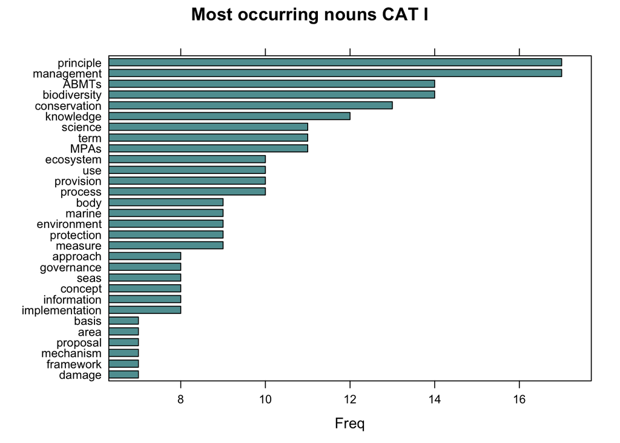

```r
statsUDP.I <- statsUDP(resI)
statsUDP.I$key <- factor(statsUDP.I$key, levels = rev(statsUDP.I$key))
barchart(key ~ freq, data = head(statsUDP.I, 30), col = "cadetblue", main = "Most occurring nouns CAT I", xlab = "Freq")
```

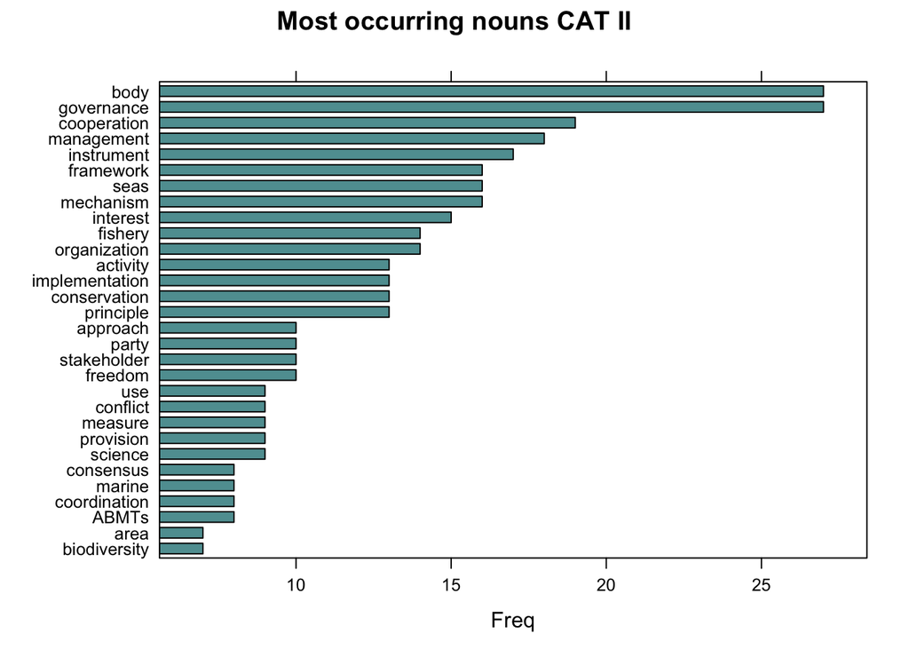

```r
statsUDP.II <- statsUDP(resII)
statsUDP.II$key <- factor(statsUDP.II$key, levels = rev(statsUDP.II$key))
barchart(key ~ freq, data = head(statsUDP.II, 30), col = "cadetblue", main = "Most occurring nouns CAT II", xlab = "Freq")
```

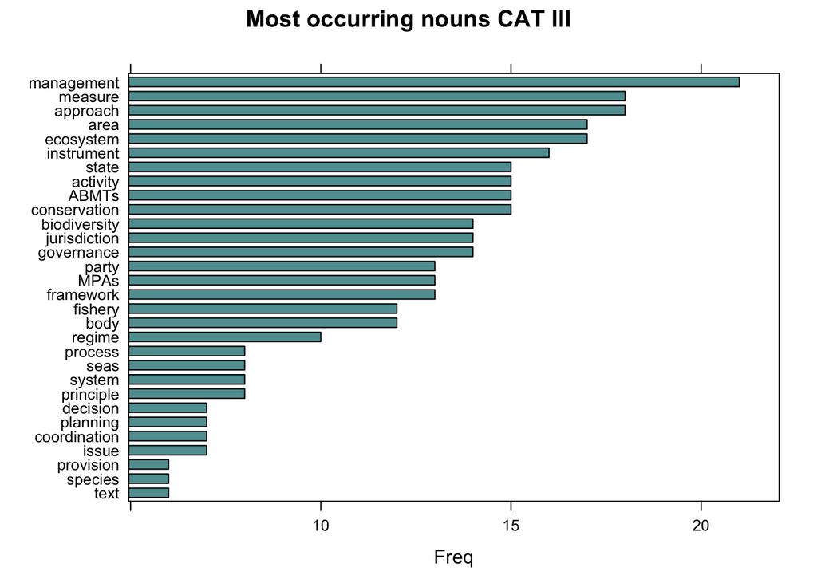

```r
statsUDP.III <- statsUDP(resIII)
statsUDP.III$key <- factor(statsUDP.III$key, levels = rev(statsUDP.III$key))
barchart(key ~ freq, data = head(statsUDP.III, 30), col = "cadetblue", main = "Most occurring nouns CAT III", xlab = "Freq")
```

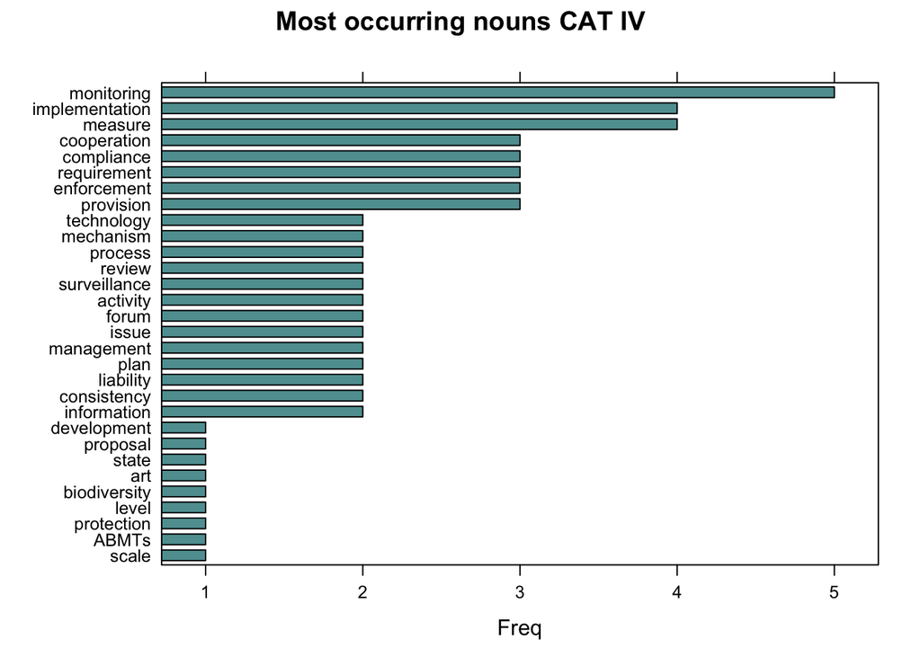

```r
statsUDP.IV <- statsUDP(resIV)
statsUDP.IV$key <- factor(statsUDP.IV$key, levels = rev(statsUDP.IV$key))
barchart(key ~ freq, data = head(statsUDP.IV, 30), col = "cadetblue", main = "Most occurring nouns CAT IV", xlab = "Freq")
```

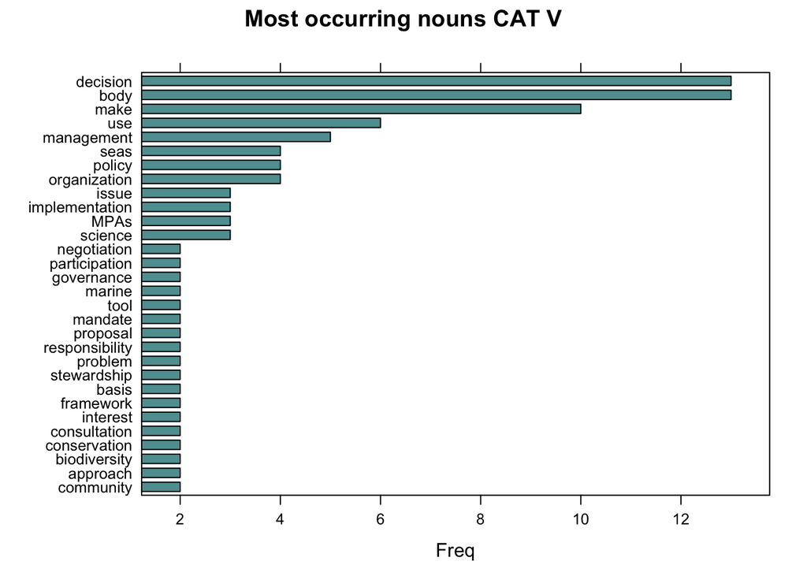

```r
statsUDP.V <- statsUDP(resV)
statsUDP.V$key <- factor(statsUDP.V$key, levels = rev(statsUDP.V$key))
barchart(key ~ freq, data = head(statsUDP.V, 30), col = "cadetblue", main = "Most occurring nouns CAT V", xlab = "Freq")
```

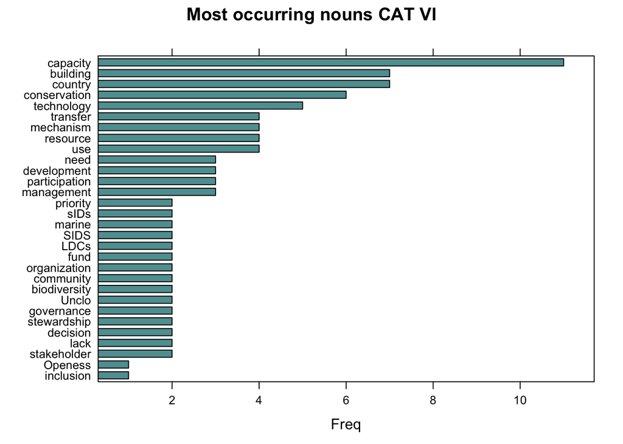

```r
statsUDP.VI <- statsUDP(resVI)
statsUDP.VI$key <- factor(statsUDP.VI$key, levels = rev(statsUDP.VI$key))
barchart(key ~ freq, data = head(statsUDP.VI, 30), col = "cadetblue", main = "Most occurring nouns CAT VI", xlab = "Freq")
```

### Option 1b: Extracting only nouns & proper nouns

Define new stats function

```r
statsUDP_npn <- function(x) {
  stats <- subset(x, upos %in% c("NOUN","PROPN"))
  stats <- txt_freq(x = stats$lemma) # x=as.character(x$Message) or x = x["Message"] in loops / lapply
}
```

Split cleaned /edited data per period

```r
resBBNJWG_e <- df_Period_e_clean %>% filter(Period==1)
resPrepCom_e <- df_Period_e_clean %>% filter(Period==2)
resIGC_e <- df_Period_e_clean %>% filter(Period==3)
```

Top 20 NOUNS or PROPN in each Negotiation phase

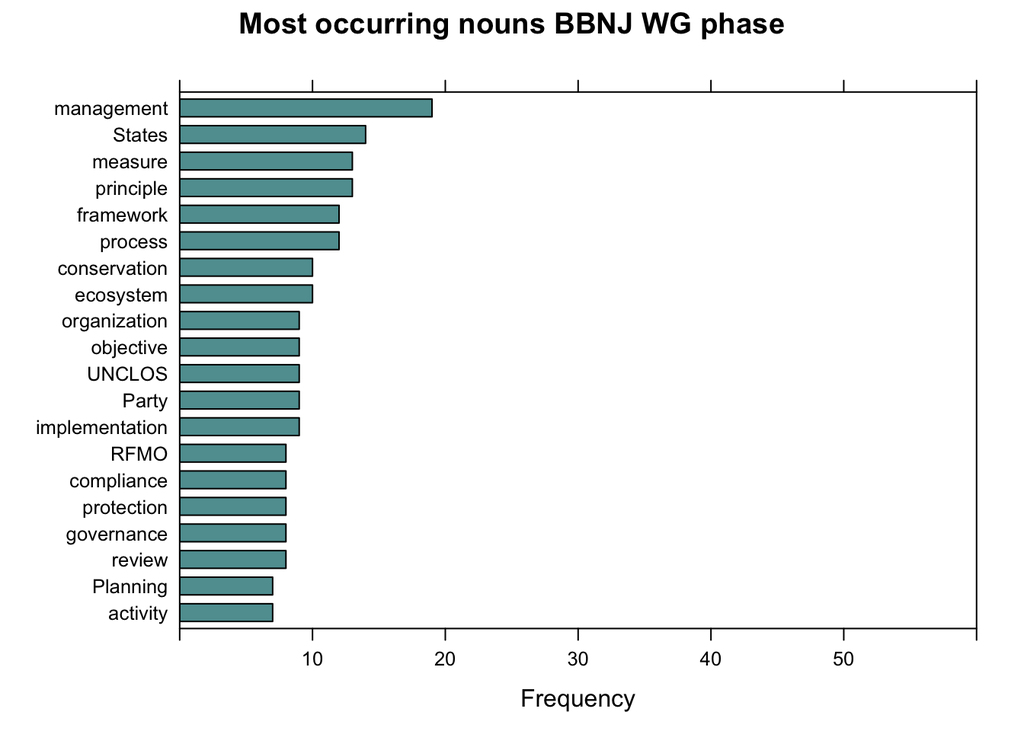

```r
statsUDP.BBNJWG <- statsUDP_npn(resBBNJWG_e)
statsUDP.BBNJWG$key <- factor(statsUDP.BBNJWG$key, levels = rev(statsUDP.BBNJWG$key))
barchart(key ~ freq, data = head(statsUDP.BBNJWG, 20), xlim= c(0, 60), col = "cadetblue", main = "Most occurring nouns BBNJ WG phase", xlab = "Frequency")
```

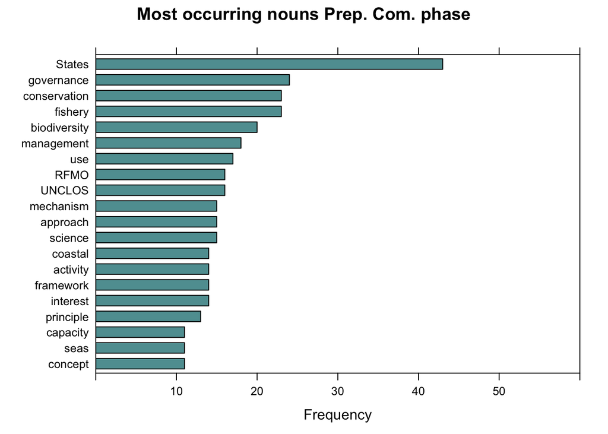

```r
statsUDP.PrepCom <- statsUDP_npn(resPrepCom_e)
statsUDP.PrepCom$key <- factor(statsUDP.PrepCom$key, levels = rev(statsUDP.PrepCom$key))
barchart(key ~ freq, data = head(statsUDP.PrepCom, 20), xlim= c(0, 60), col = "cadetblue", main = "Most occurring nouns Prep. Com. phase", xlab = "Frequency")
```

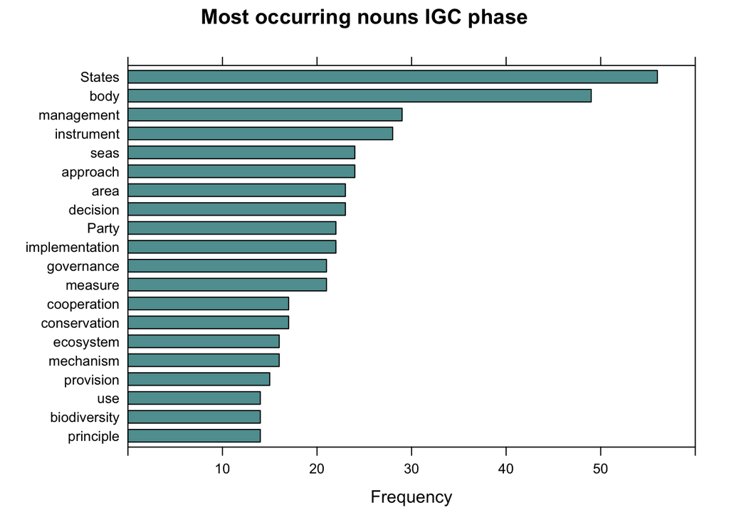

```r
statsUDP.IGC <- statsUDP_npn(resIGC_e)
statsUDP.IGC$key <- factor(statsUDP.IGC$key, levels = rev(statsUDP.IGC$key))
barchart(key ~ freq, data = head(statsUDP.IGC, 20), xlim= c(0, 60), col = "cadetblue", main = "Most occurring nouns IGC phase", xlab = "Frequency")
```

ignore - for usage out of function:

```r
#library(lattice)
# stats$key <- factor(stats$key, levels = rev(stats$key))
# barchart(key ~ freq, data = head(stats, 30), col = "cadetblue", main = "Most occurring nouns", xlab = "Freq")
```

##Below this point NOT DONE YET:

```r
# not done----
```

#‘### Option 2: Collocation & co-occurrences #’ Collocation (words following one another) colloc <- keywords_collocation(x = x, term = “token”, group = c(“doc_id”,“paragraph_id”,“sentence_id”), ngram_max = 4, n_min = 15) head(colloc)

#’ Co-occurrences: How frequent do words occur in the same sentence, in this case only nouns or adjectives Coocc1 <- cooccurrence(x = subset(x, upos %in% c(“NOUN”, “ADJ”)), term = “lemma”, group = c(“doc_id”, “paragraph_id”, “sentence_id”)) head(Coocc1) #’ Co-occurrences: How frequent do words follow one another Coocc2 <- cooccurrence(x = x$lemma, relevant = x$upos %in% c(“NOUN”, “ADJ”)) head(Coocc2) #’ Co-occurrences: How frequent do words follow one another even if we would skip 2 words in between Coocc3 <- cooccurrence(x = x$lemma, relevant = x$upos %in% c(“NOUN”, “ADJ”), skipgram = 2) head(Coocc3)

#’ Visualisation of co-occurrences using a network plot for the top 30 most frequent co-occurring nouns and adjectives. # library(igraph) # library(ggraph) # library(ggplot2) wordnetwork <- head(Coocc3, 30) wordnetwork <- graph_from_data_frame(wordnetwork) ggraph(wordnetwork, layout = “fr”) + geom_edge_link(aes(width = cooc, edge_alpha = cooc), edge_colour = “lightblue”) + geom_node_text(aes(label = name), col = “dodgerblue4”, size = 4) + theme_graph(base_family = “Arial Narrow”) + theme(legend.position = “none”) + labs(title = “Cooccurrences within 3 words distance”, subtitle = “Nouns & Adjectives”)

#‘### Option 3: Textrank (word network ordered by Google Pagerank) textrank1 <- textrank_keywords(x$lemma, relevant = x$upos %in% c(“NOUN”, “ADJ”), ngram_max = 8, sep = " ") textrank2 <- subset(textrank1$keywords, ngram > 1 & freq >= 5) #’ 5 textrank2

#’ Visualisation # library(wordcloud) wordcloud(words = textrank2$keyword, freq = textrank2$freq)

#’### Option 4: Rapid Automatic Keyword Extraction: RAKE rake <- keywords_rake(x = x, term = “token”, group = c(“doc_id”, “paragraph_id”, “sentence_id”), relevant = x$upos %in% c(“NOUN”, “ADJ”), ngram_max = 4) head(subset(rake, freq > 3))

#‘### Option 5: Phrases #’ Simple noun phrases (a adjective+noun, pre/postposition, optional determiner and another adjective+noun) x$phrase_tag <- as_phrasemachine(x$upos, type = “upos”) phrase1 <- keywords_phrases(x = x$phrase_tag, term = x$token, pattern = "(A|N)+N(P+D*(A|N)*N)*", is_regex = TRUE, ngram_max = 4, detailed = FALSE) head(subset(phrase1, ngram > 2))

#’### Option 6: Use dependency parsing output to get the nominal subject and the adjective of it Depend <- merge(x, x, by.x = c(“doc_id”, “paragraph_id”, “sentence_id”, “head_token_id”), by.y = c(“doc_id”, “paragraph_id”, “sentence_id”, “token_id”), all.x = TRUE, all.y = FALSE, suffixes = c("“,”_parent“), sort = FALSE) Depend <- subset(Depend, dep_rel %in%”nsubj" & upos %in% c(“NOUN”) & upos_parent %in% c(“ADJ”)) Depend$term <- paste(Depend$lemma_parent, Depend$lemma, sep = " ") Depend <- txt_freq(Depend$term)

# library(wordcloud)

wordcloud(words = Depend$key, freq = Depend$freq, min.freq = 4, max.words = 100, random.order = FALSE, colors = brewer.pal(6, “Dark2”))

#’ save new dataset file write.csv(x, here(“./Data/LingPartA.csv”), row.names = FALSE) # edit correct dataset name

Turn the R script into markdown output: Cmd + Shift + K